# IS YOUR FOOD SAFE?

## Outcome of Domestic Food Facilities Inspections

## Some may think food safety is not a problem in US...

### Over **300,000** Americans are hospitalized every year due to contaminated foods or beverages

### **5,000** out of those end up with *death*

### Europe outranks U.S. on food traceability and many other aspects

e.g. In the journal *Comprehensive Reviews in Food Science and Food Safety*, food traceability is ranked as **Superior** in European Union but just **Average** in U.S.

## Inspections authorites have limited resourses.

### There are **154,000** registered domestic facilities that manufacture, process, pack, or hold foods consumed by humans or animals in the United States.

### On another hand, the CFSAN is responsible for carrying out the inspections and specific tests with only a little over **800** employees.

> Center for Food Safety & Applied Nutrition (CFSAN) is one of six centers within the Food and Drug Administration (FDA). Its major responsibility is ensuring that food is safe, nutritious and wholesome, expecially milk/dairy products.

### It is necessary to more efficiently allocate resources and detect more rapidly faulty food establishments.

###### Certain states with abnormally good , only a few or censered ratings have been excluded.

## Possible inspection outcomes:

### 1. Official Action Indicated (**OAI**):

Significant objectionable conditions are found and regulatory action is warranted.

### 2. Voluntary Action Indicated (**VAI**):

Objectionable conditions are found, but not at a level that warrants regulatory action.

### 3. No Action Indicated (**NAI**):

No objectionable condition is found.

## Will the situation be different by States?

[State Effects](https://chaorenliuyi.shinyapps.io/Cpresnetation)

## It looks like TX did a better job than CA.

### 1. TX received a lot more NAI inspections and its NAI ratio is also higher than that in CA.

### 2. Where more inspections have been conducted, the overall rating seems to be better.

### 3. There are some clustering effects in inspections result.

## Yearly inspections number peaked around 2011

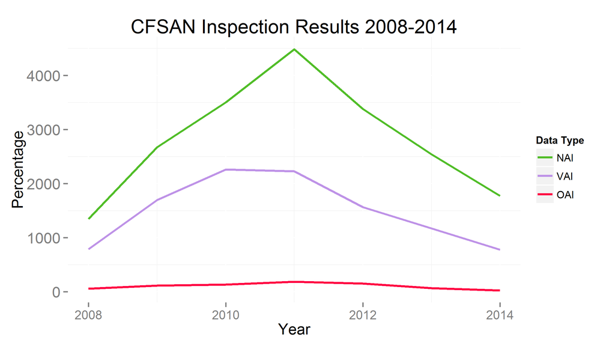

## More NAI ratings were given after 2010

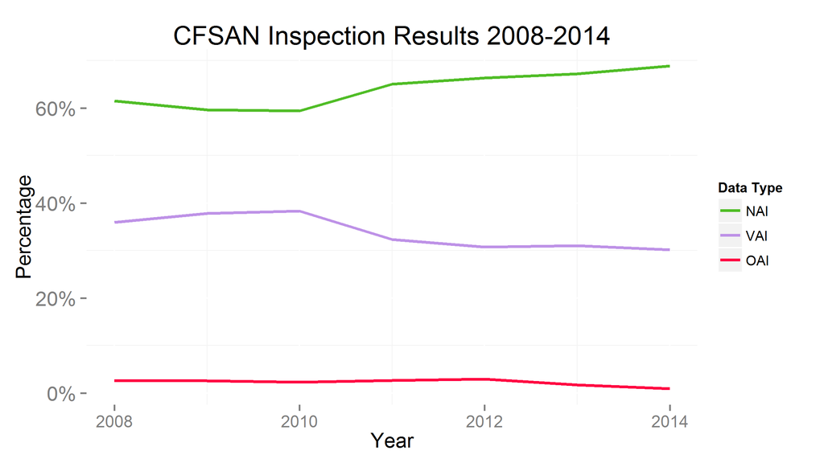

## Things went wrong in CA...

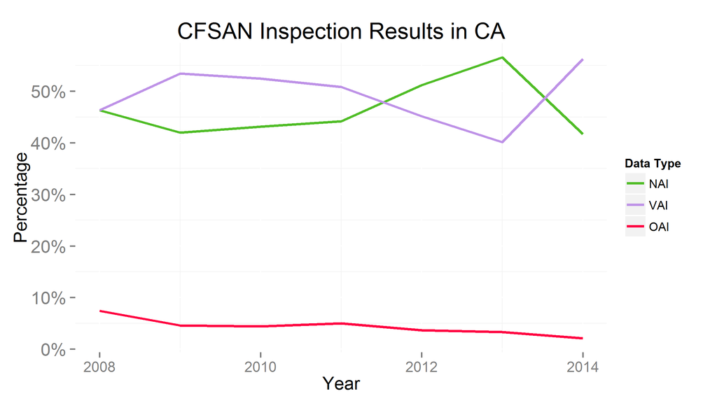

## Suggestions

### Transform some resources form **TX to CA**.

### Transform some resources form **rural areas to urban areas**.

### Investigate the cause for the **clustering effects**.

## Thank you!

## Any questions will be welcomed!